# N-Back実験

Author

伊藤史華(2412A05)

## 1. 目的 (Introduction)

本研究では、N-Back実験について検討する。N-Back実験とは、ワーキングメモリーの更新機能を測定するための実験である（(Kirchner 1958)）。 本実験の仮説は「2-Back条件は1-Back条件よりも正答率が低くなる」とした。

## 2. 方法 (Method)

### 参加者

23名のデータを収集した。

### 装置と材料

オンライン実験プラットフォーム（jsPsych）およびJavaScript（HTML/CSS）を用いて作成したN-Back課題プログラムを使用した。刺激には5種類のアルファベット大文字（A, B, C, D, E）を用い、画面中央に80px以上のフォントサイズで提示された。 課題は1-back条件（20試行）および2-back条件（20試行）の計40試行で構成された。試行刺激列はプログラム内のアルゴリズムにより事前生成され、各条件ともにターゲット試行（1つ前または2つ前と同じ文字）が厳密に6回、非ターゲット試行が14回含まれるよう、確率によらない厳格な統制が行われた。なお、比較対象が存在しない初期試行（1-back条件の1試行目、および2-back条件の1・2試行目）は自動的に非ターゲット扱いとした。 各試行のタイムラインは、刺激提示500ms、その後の刺激提示後間隔（ISI）1500msの合計2000msで固定された（`response_ends_trial: false`）。参加者の回答には、画面上の「同じ」「違う」ボタンのタップ、またはキーボードの「F」キー（同じ）および「J」キー（違う）の押下の両対応が用いられた。回答の正誤（`correct`）および反応時間（`rt`）が試行ごとにミリ秒単位で記録され、実験条件ラベル（`condition: '1-back'` または `'2-back'`）とともに保存された。

### 手続き

実験はWebブラウザ上で個別に行われた。参加者は実験開始前に課題の概要と回答方法についての教示を受け、理解した後に課題を開始した。実験は「1-back課題ブロック」、「休憩および2-back課題への教示ブロック」、「2-back課題ブロック」の順で進められた。 最初の1-back課題ブロックでは、画面中央にアルファベット（A, B, C, D, E）が1文字ずつ順番に提示された。参加者は、現在提示されている文字が「直前に提示された1つ前の文字」と同じであるか異なっているかを判断し、画面上の「同じ」「違う」ボタンをタップするか、またはキーボードの「F」キー（同じ）か「J」キー（違う）を押して回答した。1-back課題は練習なしで全20試行実施された。 1-back課題ブロックの終了後、参加者には休憩画面および2-back課題に関する新たな教示画面が提示された。教示画面では、ルールの変更（現在提示されている文字が「2つ前に提示された文字」と同じであるかを判断すること）について明確な説明が行われ、参加者が準備を整えた後にボタン操作で次の課題に進んだ。 続く2-back課題ブロックでは、2つ前に提示された文字との一致判定を行う2-back課題が全20試行実施された。回答方法およびキー割り当ては1-back課題と同様であった。 全試行において、1試行のタイムラインは「刺激（文字）提示 500ms」および「刺激提示後間隔（ISI） 1500ms」の合計 2000ms で厳密に固定された。参加者が回答を入力した場合でも即座に次の試行へ移行することはなく、回答の有無にかかわらず常に 2000ms 経過後に自動的に次の試行へと進んだ。 全40試行（1-back条件20試行、2-back条件20試行）が終了した後、参加者の画面には全試行の「条件」「試行番号」「提示刺激」「正解条件」「回答」「正誤（correct）」「反応時間（rt）」をまとめたデータ表が表示され、実験は終了した。

## 3. 結果 (Results)

以下の通り、対応のあるt検定を行った。 ワーキングメモリ負荷（1-Back条件vs.2-Back条件）が正答率に与える影響を検討するため、対応のあるt検定を行った。その結果、1-Back条件における平均正答率（M= 0.88,SD=0.17）と2-Back条件における平均正答率（M=0.84, SD=0.13）との間に統計的な有意差は認められなかった（t(22)=1.06,p=.301,95% CI[-0.03,0.10]）。したがって、ワーキングメモリ負荷の違いによって正答率に有意な差が生じるとは言えない。

```
[1] "--- 集計結果 (条件ごとの平均正答率と標準誤差) ---"
```

```
# A tibble: 2 × 5
  condition mean_accuracy sd_accuracy     n se_accuracy
  <chr>             <dbl>       <dbl> <int>       <dbl>
1 1-back            0.878       0.174    23      0.0362
2 2-back            0.844       0.128    23      0.0267
```

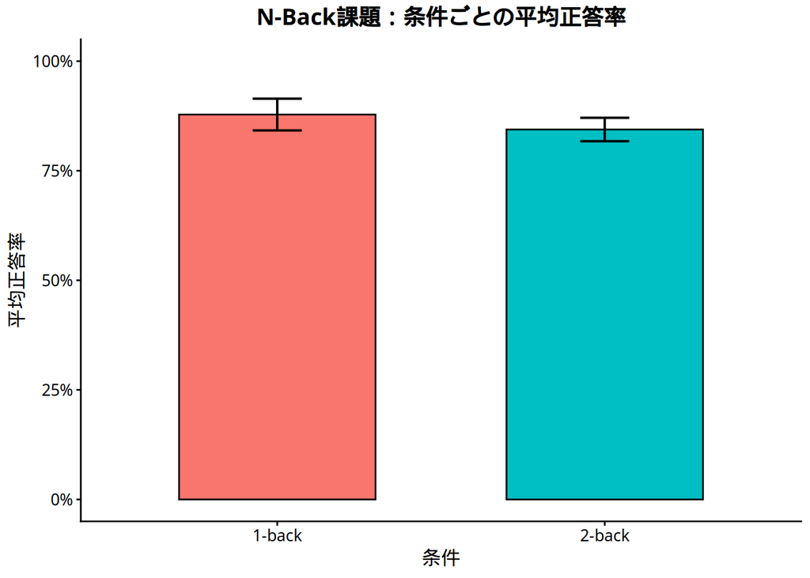

```
=== 基礎統計量（条件ごとの平均正答率と標準偏差） ===
```

```
# A tibble: 2 × 3
  condition mean_accuracy sd_accuracy
  <chr>             <dbl>       <dbl>
1 1-back            0.878       0.174
2 2-back            0.844       0.128
```

```
=== 対応のあるt検定の結果 ===
```

```
    Paired t-test

data:  data_1back and data_2back
t = 1.0595, df = 22, p-value = 0.3009
alternative hypothesis: true mean difference is not equal to 0
95 percent confidence interval:
 -0.03266083  0.10088574
sample estimates:
mean difference
     0.03411246
```

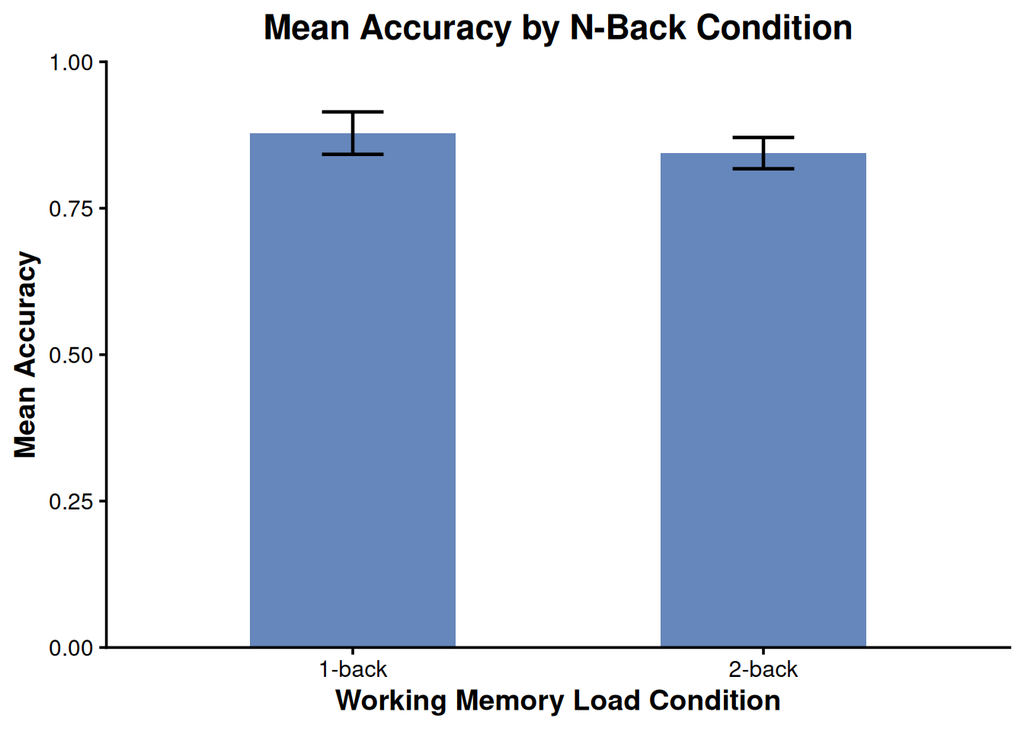

## 4. 考察 (Discussion)

分析の結果、仮説は支持されなかった。 この理由は、実験参加者に実験プログラム作成のために何度も実験に取り組んでいた認知心理学実験演習の受講者が多くいたため、慣れにより、2-Back条件の負荷が軽くなってしまったことだと推測できる。また、本実験の限界として、例題の認知度の違いが挙げられる。認知心理学実験演習の受講者以外のデータを確認した際、1-Back条件の1問目が無回答による不正解となっているものが多かった。これは、実験開始前の例題に書いてある「1問目は1つ前がないため”違う”ボタンを押す」という文を読んでいないことが原因であると推測する。

## 5. 引用文献 (References)

Kirchner, Wayne K. 1958. “Age Differences in Short-Term Retention of Rapidly Changing Information.” *Journal of Experimental Psychology* 55 (4): 352–58. https://doi.org/10.1037/h0043688.